# EDA_GoodQuality+Model_final

1. Project Overview
   1. Business Context
   2. Objective
   3. Business Questions
   4. Known Data Limitations
2. EDA
   1. Data Preparation
      1. Importing libraries and data
      2. Google Analytics
      3. Order Data
      4. Sales Data
      5. Visit Plan Data
      6. Customer Data
      7. Cutoff Time Data
      8. Operation Data
      9. Material Data
      10. Other Data Preparation Steps
   2. Abandon Analysis
      1. Device & Channel
      2. Behavioral Patterns
      3. Customer & Frequency
      4. Temporal Patterns
      5. SKU
      6. Office & Location
      7. Money Value Calculation
3. Predictive Machine Learning Model
   1. Customer Level Modeling
   2. Window Level Modeling
4. Group Contribution
5. Results

# 1. Project Overview

Created By: Xinyuan Chen, Linh Do, Mike Hanger

## A.Business Context

MyCoke360 is Swire Coca-Cola’s digital ordering platform for B2B customers such as restaurants, schools, and hospitals. Many customers add products to their online carts but fail to complete purchases before their next scheduled order date. This cart abandonment behavior causes inefficiencies in production scheduling, order fulfillment, and revenue forecasting.

## B. Project Objective

Identify behavioral patterns behind cart abandonment and recovery behavior on MyCoke360. Discover insights and actionable recommendations to increase order completion rate and reduce revenue loss.（**Note:** Cart abandonment is when a customer adds an item and does not make a purchase by the next order date.）

## C. Business Questions

**Question 1:** What (sequence of) behaviors are the strongest predictors of cart abandonment?  
**KPI:** Frequency and type of events before abandonment across sessions.

**Question 2:** What behaviors lead to a customer returning to the cart after abandonment?  
**Recovery:** Completed checkout after initial cart abandonment within X days.  
**KPI:** Recovery rate by user behavior / device.

**Question 3:** What does the customer do after cart abandonment? Either go to another platform or churn?  
**KPI:** Abandonment-to-alternative-method conversion rate.

**Question 4:** What are common products (SKU) in cart abandonment?  
**KPI:** Abandoned cart count and rate per material, by pack size/type, brand, flavor, etc.

**Question 5:** How does cart abandonment vary by device type and how can it be reduced?  
(Desktop vs. Mobile vs. App)  
**KPI:** Desktop vs. Mobile vs. App abandonment patterns.

## D. Known Data Limitations

**Mismatch between GA and MyCoke360:**

GA does not capture all events. This is known because some order windows in the GA data do not have a purchase event. However, there is sometimes a purchase on MyCoke360 in that order window in the Orders table.

Using the Orders table, missing purchase events are accounted for when determining abandoned carts.

- **Order table:**  
  Mismatch between “add to cart” items in GA, GA purchase items, and items in the Orders table.
- **Mobile purchases:**  
  Items purchased are blank.
- **Tracked cart contents:**  
  May not match the final purchased items (incomplete event data).
- **Purchase events in GA:**  
  May not align with order records in the Orders table.
- **Matching by date and account ID:**  
  Is unreliable, since customers sometimes place multiple orders through different channels on the same day.

# 2.EDA

This section focuses on data preparation. The main steps are summarized below.

## A. Data Preparation

### a. Importing libraries and data

```python
# Core & Utilities
import os
import re
import glob
import json
import warnings
from pathlib import Path
from collections import Counter
from itertools import chain
from datetime import datetime, date, time, timedelta
from zoneinfo import ZoneInfo

# Data
import numpy as np
import pandas as pd

# Visualization
import matplotlib.pyplot as plt
import seaborn as sns
import plotly.express as px
from IPython.display import display, HTML

# Statistics
from scipy import stats

# ML: preprocessing, modeling, evaluation
from sklearn.preprocessing import LabelEncoder, OneHotEncoder, StandardScaler
from sklearn.model_selection import train_test_split, StratifiedKFold, cross_val_score
from sklearn.compose import ColumnTransformer
from sklearn.pipeline import Pipeline

from sklearn.cluster import KMeans
from sklearn.linear_model import LogisticRegression
from sklearn.tree import DecisionTreeClassifier
from sklearn.ensemble import RandomForestClassifier, HistGradientBoostingClassifier

from sklearn.metrics import (
    accuracy_score,
    precision_score,
    recall_score,
    f1_score,
    roc_curve,
    roc_auc_score,
    classification_report,
    confusion_matrix,
)

# Gradient Boosting Libraries
from xgboost import XGBClassifier
from lightgbm import LGBMClassifier
```

```python
# Import data
ga = pd.read_csv("google_analytics.csv")
customer = pd.read_csv("customer.csv")
cutoff_times = pd.read_csv("cutoff_times.csv")
orders = pd.read_csv("orders.csv")
sales = pd.read_csv("sales.csv")
visit_plan = pd.read_csv("visit_plan.csv", low_memory = False)
material = pd.read_csv("material.csv")
operating_hours = pd.read_csv("operating_hours.csv")
```

```python
ga
```

|  | CUSTOMER_ID | EVENT_DATE | EVENT_TIMESTAMP | EVENT_NAME | DEVICE_CATEGORY | DEVICE_MOBILE_BRAND_NAME | DEVICE_OPERATING_SYSTEM | EVENT_PAGE_NAME | EVENT_PAGE_TITLE | ITEMS |
| --- | --- | --- | --- | --- | --- | --- | --- | --- | --- | --- |
| 0 | 501508595 | 2025-04-07 | 2025-04-07T14:57:40.713Z | view_search_results | mobile | Samsung | Android | Product List | NaN | [] |
| 1 | 501730915 | 2025-04-07 | 2025-04-07T19:28:54.546Z | view_item_list | desktop | Google | Windows | NaN | Search | [{"item_id":"158520","quantity":"1"},{"item_id... |
| 2 | 501567329 | 2025-04-07 | 2025-04-07T21:40:56.281Z | purchase | desktop | Google | Windows | MyCoke Orders - Purchase Success | Order | [{"item_id":"138335","quantity":"2"},{"item_id... |
| 3 | 501765083 | 2025-04-08 | 2025-04-08T06:06:36.717Z | user_engagement | mobile | Apple | iOS | NaN | NaN | [] |
| 4 | 501707837 | 2025-04-08 | 2025-04-08T18:12:10.511Z | view_item_list | desktop | Google | Windows | MyCoke Orders | Category: All Products | [{"item_id":"412588","quantity":"1"},{"item_id... |
| ... | ... | ... | ... | ... | ... | ... | ... | ... | ... | ... |
| 3704083 | 501652046 | 2024-06-20 | 2024-06-20T16:41:32.073Z | page_view | mobile | Apple | iOS | NaN | myWallet | [] |
| 3704084 | 600253379 | 2024-06-16 | 2024-06-16T05:51:24.993Z | button_click | desktop | Google | Windows | MyCoke Orders | Category: All Products | [] |
| 3704085 | 500926930 | 2024-06-10 | 2024-06-11T02:20:56.336Z | page_view | desktop | Google | Windows | MyCoke Orders | Category | [] |
| 3704086 | 600054564 | 2025-03-22 | 2025-03-22T21:31:57.667Z | view_item_list | desktop | Microsoft | Windows | MyCoke Orders | Category: All Products | [] |
| 3704087 | 600103578 | 2025-03-07 | 2025-03-07T22:37:57.247Z | begin_checkout | desktop | Microsoft | Windows | MyCoke Orders - Cart | Cart | [{"item_id":"110802","quantity":"2"},{"item_id... |

3704088 rows × 10 columns

```python
unique_count = ga['CUSTOMER_ID'].nunique()


unique_count
```

```
6334
```

### b. Google Analytics

```python
ga.info()
ga.describe(include='all')
ga.isna().sum()
```

```
<class 'pandas.core.frame.DataFrame'>
RangeIndex: 3704088 entries, 0 to 3704087
Data columns (total 10 columns):
 #   Column                    Dtype
---  ------                    -----
 0   CUSTOMER_ID               int64
 1   EVENT_DATE                object
 2   EVENT_TIMESTAMP           object
 3   EVENT_NAME                object
 4   DEVICE_CATEGORY           object
 5   DEVICE_MOBILE_BRAND_NAME  object
 6   DEVICE_OPERATING_SYSTEM   object
 7   EVENT_PAGE_NAME           object
 8   EVENT_PAGE_TITLE          object
 9   ITEMS                     object
dtypes: int64(1), object(9)
memory usage: 282.6+ MB
```

```
CUSTOMER_ID                       0
EVENT_DATE                        0
EVENT_TIMESTAMP                   0
EVENT_NAME                        0
DEVICE_CATEGORY                   0
DEVICE_MOBILE_BRAND_NAME      39468
DEVICE_OPERATING_SYSTEM           0
EVENT_PAGE_NAME             1002510
EVENT_PAGE_TITLE             318091
ITEMS                             0
dtype: int64
```

```python
# Convert data dates & timestamps
ga['EVENT_DATE'] = pd.to_datetime(ga['EVENT_DATE'])
ga['EVENT_TIMESTAMP'] = pd.to_datetime(ga['EVENT_TIMESTAMP'])

# Ensure categorical columns are set properly
categorical_cols = ['EVENT_NAME','DEVICE_CATEGORY',
                    'DEVICE_MOBILE_BRAND_NAME','DEVICE_OPERATING_SYSTEM',
                    'EVENT_PAGE_NAME','EVENT_PAGE_TITLE']
for col in categorical_cols:
    ga[col] = ga[col].astype('category')

# remove duplication
ga = ga.drop_duplicates()

# Handle Missing Value
ga['DEVICE_MOBILE_BRAND_NAME'] = ga['DEVICE_MOBILE_BRAND_NAME'].cat.add_categories("Unknown").fillna("Unknown")
ga['EVENT_PAGE_NAME'] = ga['EVENT_PAGE_NAME'].cat.add_categories("No_Page").fillna("No_Page")
ga['EVENT_PAGE_TITLE'] = ga['EVENT_PAGE_TITLE'].cat.add_categories("Untitled").fillna("Untitled")

# Convert event_timestamp from ETC to
ga['EVENT_TIMESTAMP'] = pd.to_datetime(ga['EVENT_TIMESTAMP'], errors='coerce')
ga['EVENT_TIMESTAMP'] = ga['EVENT_TIMESTAMP'].dt.tz_convert('UTC')
```

```python
ga.isna().sum()
```

```
CUSTOMER_ID                 0
EVENT_DATE                  0
EVENT_TIMESTAMP             0
EVENT_NAME                  0
DEVICE_CATEGORY             0
DEVICE_MOBILE_BRAND_NAME    0
DEVICE_OPERATING_SYSTEM     0
EVENT_PAGE_NAME             0
EVENT_PAGE_TITLE            0
ITEMS                       0
dtype: int64
```

```python
#plt.figure(figsize=(14,6))

#ga['EVENT_NAME'].value_counts(dropna = False).head(10).plot(kind = 'bar')
#plt.title('Distribution of event name: action the customer took')
#plt.show()
```

```python
#plt.figure(figsize=(14,6))

#ga['DEVICE_OPERATING_SYSTEM'].value_counts(dropna = False).plot(kind = 'bar')
#plt.title('Distribution of device operating systems')
#plt.show()
```

```python
#plt.figure(figsize=(14,6))

#ga['DEVICE_MOBILE_BRAND_NAME'].value_counts(dropna = False).plot(kind = 'bar')
#plt.title('Distribution of DEVICE_MOBILE_BRAND_NAME: brand of deviced used')
#plt.show()
```

### c. Order Data

```python
orders.info()
orders.describe(include='all')
orders.isna().sum()
```

```
<class 'pandas.core.frame.DataFrame'>
RangeIndex: 1662157 entries, 0 to 1662156
Data columns (total 7 columns):
 #   Column            Non-Null Count    Dtype
---  ------            --------------    -----
 0   CUSTOMER_ID       1662157 non-null  int64
 1   CREATED_DATE_EST  1662157 non-null  object
 2   CREATED_DATE_UTC  1662157 non-null  object
 3   MATERIAL_ID       1661962 non-null  float64
 4   ORDER_QUANTITY    1662157 non-null  float64
 5   ORDER_TYPE        1662157 non-null  object
 6   PLANT_ID          1662146 non-null  object
dtypes: float64(2), int64(1), object(4)
memory usage: 88.8+ MB
```

```
CUSTOMER_ID           0
CREATED_DATE_EST      0
CREATED_DATE_UTC      0
MATERIAL_ID         195
ORDER_QUANTITY        0
ORDER_TYPE            0
PLANT_ID             11
dtype: int64
```

```python
# Convert data type
orders['CREATED_DATE_EST'] = pd.to_datetime(orders['CREATED_DATE_EST'])
orders['CREATED_DATE_UTC'] = pd.to_datetime(orders['CREATED_DATE_UTC'])
orders['MATERIAL_ID'] = orders['MATERIAL_ID'].astype('Int64')

# Handle missing values
orders = orders.dropna()

# Convert categorical
orders.loc[:, 'ORDER_TYPE'] = orders['ORDER_TYPE'].astype('category')

# Remove any duplicate lines
orders = orders.drop_duplicates()

# Convert Orders timestamp to match GA UTC format
orders["CREATED_DATE_UTC"] = pd.to_datetime(orders["CREATED_DATE_UTC"], utc=True)
```

```python
# Verify all NAs are removed
orders.isna().sum()
```

```
CUSTOMER_ID         0
CREATED_DATE_EST    0
CREATED_DATE_UTC    0
MATERIAL_ID         0
ORDER_QUANTITY      0
ORDER_TYPE          0
PLANT_ID            0
dtype: int64
```

### d. Sales Data

```python
sales.info()
sales.describe(include='all')
sales.isna().sum()
sales.isna().sum() / len(sales) * 100
```

```
<class 'pandas.core.frame.DataFrame'>
RangeIndex: 499787 entries, 0 to 499786
Data columns (total 6 columns):
 #   Column                 Non-Null Count   Dtype
---  ------                 --------------   -----
 0   CUSTOMER_ID            499787 non-null  int64
 1   POSTING_DATE           499787 non-null  object
 2   MATERIAL_ID            499787 non-null  int64
 3   GROSS_PROFIT_DEAD_NET  499787 non-null  float64
 4   PHYSICAL_VOLUME        499787 non-null  float64
 5   NSI_DEAD_NET           499787 non-null  float64
dtypes: float64(3), int64(2), object(1)
memory usage: 22.9+ MB
```

```
CUSTOMER_ID              0.0
POSTING_DATE             0.0
MATERIAL_ID              0.0
GROSS_PROFIT_DEAD_NET    0.0
PHYSICAL_VOLUME          0.0
NSI_DEAD_NET             0.0
dtype: float64
```

```python
# convert to datetime
sales['POSTING_DATE'] = pd.to_datetime(sales['POSTING_DATE'])

# Ensure categorical/numeric consistency
sales['CUSTOMER_ID'] = sales['CUSTOMER_ID'].astype(int)
sales['MATERIAL_ID'] = sales['MATERIAL_ID'].astype(int)

# Remove any duplicates
sales = sales.drop_duplicates()
```

### e. Visit Plan Data

```python
visit_plan.info()
visit_plan.describe(include='all')
visit_plan.isna().sum() / len(visit_plan) * 100
```

```
<class 'pandas.core.frame.DataFrame'>
RangeIndex: 13638683 entries, 0 to 13638682
Data columns (total 9 columns):
 #   Column                    Dtype
---  ------                    -----
 0   CUSTOMER_ID               int64
 1   FREQUENCY                 object
 2   ELT_TS                    object
 3   SNAPSHOT_DATE             object
 4   ANCHOR_DATE               object
 5   SALES_OFFICE              object
 6   SALES_OFFICE_DESC         object
 7   DISTRIBUTION_MODE         object
 8   SHIPPING_CONDITIONS_DESC  object
dtypes: int64(1), object(8)
memory usage: 936.5+ MB
```

```
CUSTOMER_ID                 0.000000
FREQUENCY                   0.102363
ELT_TS                      0.000000
SNAPSHOT_DATE               0.000000
ANCHOR_DATE                 0.102371
SALES_OFFICE                0.000543
SALES_OFFICE_DESC           0.000543
DISTRIBUTION_MODE           0.112152
SHIPPING_CONDITIONS_DESC    0.000543
dtype: float64
```

```python
# Drop rows missing key dates or values
visit_plan = visit_plan.dropna(subset=['ANCHOR_DATE']).dropna()

# Convert datetime columns
visit_plan['ELT_TS'] = pd.to_datetime(visit_plan['ELT_TS'], errors='coerce', utc=True)
visit_plan['SNAPSHOT_DATE'] = pd.to_datetime(visit_plan['SNAPSHOT_DATE'], errors='coerce')
visit_plan['ANCHOR_DATE'] = pd.to_datetime(visit_plan['ANCHOR_DATE'], errors='coerce')

# Make elt_date into formate mathc ga data set
visit_plan["ELT_TS"] = pd.to_datetime(visit_plan["ELT_TS"], utc=True)

# Convert categorical columns
cat_cols = [
    'FREQUENCY', 'SALES_OFFICE', 'SALES_OFFICE_DESC',
    'DISTRIBUTION_MODE', 'SHIPPING_CONDITIONS_DESC'
]
visit_plan[cat_cols] = visit_plan[cat_cols].astype('category')

# Remove duplicates
visit_plan = visit_plan.drop_duplicates().copy()

# Quick checks
#print("Missing values per column:\n", visit_plan.isna().sum())
#print("\nUnique counts per column:\n", visit_plan.nunique())
```

```python
#plt.figure(figsize=(14,6))

#visit_plan['SALES_OFFICE'].value_counts(dropna = False).plot(kind = 'bar')
#plt.title('Distribution of  sales office the customer orders from')
#plt.show()
```

```python
#plt.figure(figsize=(14,6))

#visit_plan['SALES_OFFICE_DESC'].value_counts(dropna = False).plot(kind = 'bar')
#plt.title('Distribution of  city of sales office the customer orders from')
#plt.show()
```

```python
#visit_plan['DISTRIBUTION_MODE'].value_counts(dropna = False).plot(kind = 'bar')
#plt.title('Distribution of mode of distribution')
#plt.show()
```

### f. Customer Data

```python
customer.info()
customer.describe(include='all')
customer.isna().sum()
customer.isna().sum() / len(visit_plan) * 100
```

```
<class 'pandas.core.frame.DataFrame'>
RangeIndex: 6334 entries, 0 to 6333
Data columns (total 7 columns):
 #   Column                                  Non-Null Count  Dtype
---  ------                                  --------------  -----
 0   SALES_OFFICE                            6334 non-null   object
 1   CUSTOMER_NUMBER                         6334 non-null   int64
 2   SALES_OFFICE_DESCRIPTION                6334 non-null   object
 3   DISTRIBUTION_MODE_DESCRIPTION           6330 non-null   object
 4   SHIPPING_CONDITIONS_DESCRIPTION         6334 non-null   object
 5   COLD_DRINK_CHANNEL_DESCRIPTION          6334 non-null   object
 6   CUSTOMER_SUB_TRADE_CHANNEL_DESCRIPTION  6334 non-null   object
dtypes: int64(1), object(6)
memory usage: 346.5+ KB
```

```
SALES_OFFICE                              0.000000
CUSTOMER_NUMBER                           0.000000
SALES_OFFICE_DESCRIPTION                  0.000000
DISTRIBUTION_MODE_DESCRIPTION             0.000037
SHIPPING_CONDITIONS_DESCRIPTION           0.000000
COLD_DRINK_CHANNEL_DESCRIPTION            0.000000
CUSTOMER_SUB_TRADE_CHANNEL_DESCRIPTION    0.000000
dtype: float64
```

```python
# Rename customer ID to align with other tables
customer = customer.rename(columns={'CUSTOMER_NUMBER': 'CUSTOMER_ID'})

# Fill missing values in distribution mode
customer['DISTRIBUTION_MODE_DESCRIPTION'] = customer['DISTRIBUTION_MODE_DESCRIPTION'].fillna("Unknown")

# Convert categorical fields
cat_cols = [
    'SALES_OFFICE',
    'SALES_OFFICE_DESCRIPTION',
    'DISTRIBUTION_MODE_DESCRIPTION',
    'SHIPPING_CONDITIONS_DESCRIPTION',
    'COLD_DRINK_CHANNEL_DESCRIPTION',
    'CUSTOMER_SUB_TRADE_CHANNEL_DESCRIPTION'
]
for col in cat_cols:
    customer[col] = customer[col].astype('category')

# Drop any duplicates
customer = customer.drop_duplicates()
```

```python
#plt.figure(figsize=(14,6))

#customer['COLD_DRINK_CHANNEL_DESCRIPTION'].value_counts(dropna = 'False').plot(kind = 'bar')
#plt.title('Distribution of COLD_DRINK_CHANNEL_DESCRIPTION: customer industry')
#plt.show()
```

```python
#plt.figure(figsize=(14,6))

#customer['CUSTOMER_SUB_TRADE_CHANNEL_DESCRIPTION'].value_counts(dropna = 'False').head(10).plot(kind = 'bar')
#plt.title('Distribution of CUSTOMER_SUB_TRADE_CHANNEL_DESCRIPTION: customer  segment')
#plt.show()
```

### g. Cutoff Time Data

```python
cutoff_times.info()
cutoff_times.describe(include='all')
cutoff_times.isna().sum()
```

```
<class 'pandas.core.frame.DataFrame'>
RangeIndex: 220 entries, 0 to 219
Data columns (total 5 columns):
 #   Column                   Non-Null Count  Dtype
---  ------                   --------------  -----
 0   SALES_OFFICE             220 non-null    object
 1   PLANT_ID                 220 non-null    object
 2   CUTOFFTIME__C            220 non-null    object
 3   SHIPPING_CONDITION_TIME  220 non-null    object
 4   DISTRIBUTION_MODE        220 non-null    object
dtypes: object(5)
memory usage: 8.7+ KB
```

```
SALES_OFFICE               0
PLANT_ID                   0
CUTOFFTIME__C              0
SHIPPING_CONDITION_TIME    0
DISTRIBUTION_MODE          0
dtype: int64
```

```python
# Convert to categorical
cat_cols = ['SALES_OFFICE', 'PLANT_ID', 'SHIPPING_CONDITION_TIME', 'DISTRIBUTION_MODE']
cutoff_times[cat_cols] = cutoff_times[cat_cols].astype('category')

# Drop duplicates
cutoff_times = cutoff_times.drop_duplicates()

# Remove "0" from the  SALES_OFFICE Variable
cutoff_times = cutoff_times[
    (cutoff_times['SALES_OFFICE'] != '0') &
    (cutoff_times['PLANT_ID'] != '0')
].copy()

# quick check
#cutoff_times.head()
```

```python
#plt.figure(figsize=(14,6))

#cutoff_times['SALES_OFFICE'].value_counts(dropna = False).plot(kind = 'bar')
#plt.title('Distribution of sales office the customer orders from')
#plt.show()
```

```python
#cutoff_times['SHIPPING_CONDITION_TIME'].value_counts(dropna = False).plot(kind = 'bar')
#plt.title('Distribution of SHIPPING_CONDITION_TIME')
#plt.show()
```

### h. Operation Data

```python
operating_hours.info()
operating_hours.describe(include='all')
operating_hours.isna().sum()
```

```
<class 'pandas.core.frame.DataFrame'>
RangeIndex: 6202 entries, 0 to 6201
Data columns (total 4 columns):
 #   Column               Non-Null Count  Dtype
---  ------               --------------  -----
 0   CUSTOMER_NUMBER      6202 non-null   int64
 1   FREQUENCY            6202 non-null   object
 2   DELIVERY_ANCHOR_DAY  6202 non-null   object
 3   CALLING_ANCHOR_DATE  6202 non-null   object
dtypes: int64(1), object(3)
memory usage: 193.9+ KB
```

```
CUSTOMER_NUMBER        0
FREQUENCY              0
DELIVERY_ANCHOR_DAY    0
CALLING_ANCHOR_DATE    0
dtype: int64
```

```python
# Rename for consistency
operating_hours = operating_hours.rename(columns={'CUSTOMER_NUMBER': 'CUSTOMER_ID'})

# Convert date
operating_hours['CALLING_ANCHOR_DATE'] = pd.to_datetime(
    operating_hours['CALLING_ANCHOR_DATE'], errors='coerce'
)

# Convert categorical fields
cat_cols = ['FREQUENCY', 'DELIVERY_ANCHOR_DAY']
for col in cat_cols:
    operating_hours[col] = operating_hours[col].astype('category')

# Remove any duplicates
operating_hours = operating_hours.drop_duplicates()

# Quick check
#print(operating_hours.dtypes)
#print(operating_hours.head())
```

```python
#operating_hours['FREQUENCY'].value_counts(dropna = False).plot(kind = 'bar')
#plt.title('Distribution of FREQUENCY: how often a customer will receive deliveries')
#plt.show()
```

```python
#operating_hours['DELIVERY_ANCHOR_DAY'].value_counts(dropna = False).plot(kind = 'bar')
#plt.title('Distribution of DELIVERY_ANCHOR_DAY: the day customer will receive deliveries')
#plt.show()
```

### i. Material Data

```python
material.info()
material.describe(include='all')
material.isna().sum()
```

```
<class 'pandas.core.frame.DataFrame'>
RangeIndex: 1252 entries, 0 to 1251
Data columns (total 6 columns):
 #   Column           Non-Null Count  Dtype
---  ------           --------------  -----
 0   MATERIAL_ID      1252 non-null   int64
 1   PACK_TYPE_DESC   1252 non-null   object
 2   TRADE_MARK_DESC  1252 non-null   object
 3   FLAVOUR_DESC     1252 non-null   object
 4   PACK_SIZE_DESC   1252 non-null   object
 5   BEV_CAT_DESC     1118 non-null   object
dtypes: int64(1), object(5)
memory usage: 58.8+ KB
```

```
MATERIAL_ID          0
PACK_TYPE_DESC       0
TRADE_MARK_DESC      0
FLAVOUR_DESC         0
PACK_SIZE_DESC       0
BEV_CAT_DESC       134
dtype: int64
```

```python
# Fill missing values
material.loc[material['BEV_CAT_DESC'].isna(), 'BEV_CAT_DESC'] = 'CONTAINER/LID'

# Convert selected columns to categorical
cat_cols = [
    'PACK_TYPE_DESC',
    'TRADE_MARK_DESC',
    'FLAVOUR_DESC',
    'PACK_SIZE_DESC',
    'BEV_CAT_DESC'
]
material[cat_cols] = material[cat_cols].astype('category')

# check
#material.nunique()
```

```python
#plt.figure(figsize=(14,6))
#material['TRADE_MARK_DESC'].value_counts(dropna = False).plot(kind = 'bar')
#plt.title('Distribution of TRADE_MARK_DESC')
#plt.show()
```

```python
#plt.figure(figsize=(14,6))
#material['BEV_CAT_DESC'].value_counts(dropna = False).plot(kind = 'bar')
#plt.title('Distribution of BEV_CAT_DESC')
#plt.show()
```

```python
#plt.figure(figsize=(14,6))
#material['PACK_TYPE_DESC'].value_counts(dropna = False).plot(kind = 'bar')
#plt.title('Distribution of package type')
#plt.show()
```

```python
#plt.figure(figsize=(14,6))

#material['PACK_SIZE_DESC'].value_counts(dropna = False).head(10).plot(kind = 'bar')
#plt.title('Distribution of PACK_SIZE_DESC: product size')
#plt.show()
```

### j. Other Data Preparation Steps

We define **abandonment** as when a customer **adds an item to their cart but does not complete a purchase before their next expected order date**.

- `added_in_window` = True if the customer added to cart during the reorder window
- `purchased_in_window` = True if they made a purchase (either in GA or Orders) during that same window
- `is_abandoned = added_in_window AND NOT purchased_in_window`

In other words, a customer is marked **abandoned (1)** only if they showed purchase intent but didn’t follow through.

We also create a second label, **`missed_reorder`**, which marks customers who simply didn’t purchase by their next expected due date—regardless of whether they added to cart or not.

```python
# Standardize column names across all tables
def clean_columns(df):
    df = df.copy()
    df.columns = (
        df.columns.str.strip()
                  .str.lower()
                  .str.replace('__', '_', regex=False)
                  .str.replace(' ', '_', regex=False)
    )
    return df

ga           = clean_columns(ga)
orders       = clean_columns(orders)
sales        = clean_columns(sales)
visit_plan   = clean_columns(visit_plan)
customer     = clean_columns(customer)
cutoff_times = clean_columns(cutoff_times)
operating_hours = clean_columns(operating_hours)
material     = clean_columns(material)
```

```python
# change frequency to days
freq_map = {'01': 7, '02': 14, '04': 28}
visit_plan['frequency_days'] = visit_plan['frequency'].map(freq_map)
```

```python
# Timestamp normalization

ga['event_timestamp'] = ga['event_timestamp'].dt.tz_convert('UTC')
ga['event_date_utc']  = ga['event_timestamp'].dt.normalize()

orders['created_date_utc'] = orders['created_date_utc'].dt.tz_convert('UTC')
orders['order_date_utc']   = orders['created_date_utc'].dt.normalize()
```

Below code chunk will create dataset `ga2`:

- Event-level view of myCoke360 activity.
- One row = one website event for a customer (page view, add_to_cart, remove_from_cart, purchase, etc.).
- Built from Google Analytics events and enriched with scheduling fields (e.g., next expected order date) and customer/order context.
- Used to analyze how customers behave online within each order window before an order is placed or a cart is abandoned.

```python
# Clean and deduplicate visit_plan
visit_plan = (
    visit_plan
    .drop_duplicates(subset=['customer_id', 'anchor_date'], keep='last')
    .sort_values(['customer_id', 'anchor_date'])
)

# Define each policy’s active window
#   effective_start = when this policy starts
#   effective_end   = when the NEXT policy starts

visit_plan['effective_start'] = visit_plan['anchor_date']
visit_plan['effective_end']   = visit_plan.groupby('customer_id')['anchor_date'].shift(-1)
visit_plan['effective_end']   = visit_plan['effective_end'].fillna(pd.Timestamp('2100-01-01'))


# Ensure UTC awareness on policy windows

visit_plan['effective_start'] = visit_plan['effective_start'].dt.tz_localize(
    'UTC', nonexistent='shift_forward'
)
visit_plan['effective_end'] = visit_plan['effective_end'].dt.tz_localize(
    'UTC', nonexistent='shift_forward'
)


# Attach correct policy row to each GA event

ga2 = ga.merge(visit_plan, on='customer_id', how='left')

ga2 = ga2[
    (ga2['event_timestamp'] >= ga2['effective_start']) &
    (ga2['event_timestamp'] <  ga2['effective_end'])
].copy()


# Compute next expected order date (next_due)

def next_due(event_ts, anchor_ts, freq_days):
    # Guard rails
    if pd.isna(anchor_ts) or pd.isna(freq_days) or int(freq_days) <= 0:
        return pd.NaT

    # Ensure tz-aware UTC
    if event_ts.tzinfo is None:
        event_ts = event_ts.tz_localize('UTC')
    else:
        event_ts = event_ts.tz_convert('UTC')

    if anchor_ts.tzinfo is None:
        anchor_ts = anchor_ts.tz_localize('UTC')
    else:
        anchor_ts = anchor_ts.tz_convert('UTC')

    # How many full cycles have passed since anchor?
    # We add 1 so the returned time is strictly the "next" due after the event.
    delta = event_ts - anchor_ts
    k = max(0, int(delta // pd.Timedelta(days=int(freq_days))) + 1)

    return anchor_ts + pd.Timedelta(days=int(freq_days) * k)


ga2['next_order_date_utc'] = ga2.apply(
    lambda r: next_due(r['event_timestamp'], r['anchor_date'], r['frequency_days']),
    axis=1
)


# Build per-customer lookup sets (UTC dates)

def _dateset(s):
    # Input: tz-aware series of datetimes
    if s.empty:
        return set()
    return set(s.dt.normalize())


# GA add_to_cart dates, per customer
ga_add = (
    ga.loc[
        ga['event_name'].astype(str).str.lower().eq('add_to_cart'),
        ['customer_id', 'event_date_utc']
    ]
    .groupby('customer_id')['event_date_utc']
    .apply(_dateset)
    .to_dict()
)

# GA purchase dates, per customer
ga_pur = (
    ga.loc[
        ga['event_name'].astype(str).str.lower().eq('purchase'),
        ['customer_id', 'event_date_utc']
    ]
    .groupby('customer_id')['event_date_utc']
    .apply(_dateset)
    .to_dict()
)

# Orders purchase dates, per customer
ord_pur = (
    orders[['customer_id', 'order_date_utc']]
    .groupby('customer_id')['order_date_utc']
    .apply(_dateset)
    .to_dict()
)


# For each GA event row, flag activity in the window

def any_in_window(dates_set, start_d, end_d):
    if not dates_set:
        return False
    # sets contain tz-aware normalized midnights; compare inclusive range
    return any((d >= start_d) and (d <= end_d) for d in dates_set)


def flags_for_row(row):
    # If we don't have a next due, we can't form a window
    if pd.isna(row['next_order_date_utc']):
        return pd.Series([False, False])

    start_d = row['event_date_utc'].tz_convert('UTC').normalize()
    end_d   = row['next_order_date_utc'].tz_convert('UTC').normalize()

    adds = ga_add.get(row['customer_id'], set())
    gp   = ga_pur.get(row['customer_id'], set())
    op   = ord_pur.get(row['customer_id'], set())

    added_flag      = any_in_window(adds, start_d, end_d)
    purchased_flag  = any_in_window(gp, start_d, end_d) or any_in_window(op, start_d, end_d)

    return pd.Series([added_flag, purchased_flag])


ga2[['added_in_window', 'purchased_in_window']] = ga2.apply(flags_for_row, axis=1)


# Collapse to unique (customer, next_due) windows
windows = (
    ga2.dropna(subset=['next_order_date_utc'])
       .groupby(['customer_id', 'next_order_date_utc'], as_index=False)
       .agg(
           added_in_window=('added_in_window', 'max'),
           purchased_in_window=('purchased_in_window', 'max')
       )
)
```

Below code chunk will create the `windows` dataset:

- One row per customer and expected order date (order window).
- Each row represents the period between two expected orders for that customer.
- Carries forward flags from `ga2` that indicate whether items were added to cart and whether a purchase occurred in that window.
- Used to classify each order window as “had activity and purchase”, “had activity but no purchase (potential abandonment)”, or “no activity”.

```python
# Keep only rows with a valid next_order_date_utc
ga2_valid = ga2.dropna(subset=['next_order_date_utc'])

# Collapse to unique (customer, next_due) windows, but keep device & context info
windows = (
    ga2_valid
    .groupby(['customer_id', 'next_order_date_utc'], as_index=False)
    .agg(
        added_in_window=('added_in_window', 'max'),
        purchased_in_window=('purchased_in_window', 'max'),
        device_category=('device_category', lambda x: x.mode().iat[0] if not x.mode().empty else None),
        device_mobile_brand_name=('device_mobile_brand_name', lambda x: x.mode().iat[0] if not x.mode().empty else None),
        device_operating_system=('device_operating_system', lambda x: x.mode().iat[0] if not x.mode().empty else None),
        event_page_name=('event_page_name', lambda x: x.mode().iat[0] if not x.mode().empty else None),
        event_page_title=('event_page_title', lambda x: x.mode().iat[0] if not x.mode().empty else None),
        frequency=('frequency', 'first'),
        sales_office=('sales_office', 'first'),
        sales_office_desc=('sales_office_desc', 'first'),
        distribution_mode=('distribution_mode', 'first'),
        shipping_conditions_desc=('shipping_conditions_desc', 'first')
    )
)

# final label columns
windows['is_abandoned'] = (
    (windows['added_in_window']) &
    (~windows['purchased_in_window'])
).astype(int)

windows['missed_reorder'] = (
    ~windows['purchased_in_window']
).astype(int)
```

```python
# Check
windows['is_abandoned'].value_counts()
```

```
is_abandoned
0    49389
1     3092
Name: count, dtype: int64
```

```python
# add customer info (who is this account?)
customer_features = customer[[
    'customer_id',
    'sales_office_description',
    'shipping_conditions_description',
    'cold_drink_channel_description',
]].drop_duplicates()

windows = windows.merge(customer_features, on='customer_id', how='left')


# add Order behavior summary (how often do they actually buy?)
order_stats = (
    orders.groupby('customer_id', as_index=False)
        .agg(
            total_orders=('created_date_utc', 'count'),
            last_order_time=('created_date_utc', 'max'),
            total_units_ordered=('order_quantity', 'sum'),
            avg_units_per_order=('order_quantity', 'mean'),
        )
)

windows = windows.merge(order_stats, on='customer_id', how='left') # 50，000
```

```python
# 8b Add sequential features from GA events safely

target_events = [
    'view_item_list',
    'add_to_cart',
    'update_cart',
    'view_site_search',
    'proceed_to_checkout',
    'user_engagement'
]

# Clean event_name
ga2['event_name_clean'] = ga2['event_name'].astype(str).str.strip().str.lower()

# Filter GA to only target events
ga_filtered = ga2[ga2['event_name_clean'].isin(target_events)]

# Count each event per customer-window
event_counts = (
    ga_filtered.groupby(['customer_id', 'next_order_date_utc', 'event_name_clean'])
               .size()
               .unstack(fill_value=0)
               .reset_index()
)

# Ensure only target columns exist
event_counts = event_counts[['customer_id', 'next_order_date_utc'] + target_events]

# Device flags (0/1)
device_flags = (
    ga2.groupby(['customer_id', 'next_order_date_utc'])['device_category']
       .agg(list)
       .reset_index()
)

device_flags['access_desktop'] = device_flags['device_category'].apply(lambda x: int('desktop' in x))
device_flags['access_mobile'] = device_flags['device_category'].apply(lambda x: int('mobile' in x))
device_flags['access_tablet'] = device_flags['device_category'].apply(lambda x: int('tablet' in x))
device_flags = device_flags.drop(columns=['device_category'])

# Merge into windows
windows = (
    windows
    .merge(event_counts, on=['customer_id', 'next_order_date_utc'], how='left')
    .merge(device_flags, on=['customer_id', 'next_order_date_utc'], how='left')
)
```

```python
# 8c. Add aggregate behavioral features (activity & page views) ---

# Step 1: Clean page name
ga2['event_page_name_clean'] = ga2['event_page_name'].astype(str).str.strip().str.lower()

# Step 2: Aggregate behavioral signals per customer-window
behavior_features = (
    ga2.groupby(['customer_id', 'next_order_date_utc'])
       .agg(
           total_user_activities=('event_name', 'count'),
           unique_pages_viewed=('event_page_name_clean', lambda x: x.nunique()),
           viewed_product_details=('event_page_name_clean', lambda x: int('product details' in x.values)),
           viewed_product_list=('event_page_name_clean', lambda x: int('product list' in x.values))
       )
       .reset_index()
)

# Step 3: Merge back into windows
windows = windows.merge(behavior_features, on=['customer_id', 'next_order_date_utc'], how='left')

# Step 4: Fill missing numeric values with 0 (no activity recorded in GA for that window)
for col in ['total_user_activities', 'unique_pages_viewed', 'viewed_product_details', 'viewed_product_list']:
    windows[col] = windows[col].fillna(0)
```

```python
# 8d. Add detailed event-based features per customer-window ---

# Clean key text fields
ga2['event_name_clean'] = ga2['event_name'].astype(str).str.strip().str.lower()
ga2['event_page_name_clean'] = ga2['event_page_name'].astype(str).str.strip().str.lower()

# Aggregate key event & page activity per (customer_id, next_order_date_utc)
extra_features = (
    ga2.groupby(['customer_id', 'next_order_date_utc']).agg(
        # Event-based features
        remove_from_cart_count=('event_name_clean', lambda x: (x == 'remove_from_cart').sum()),
        begin_checkout_flag=('event_name_clean', lambda x: int('begin_checkout' in x.values)),
        view_item_count=('event_name_clean', lambda x: (x == 'view_item').sum()),
        select_item_count=('event_name_clean', lambda x: (x == 'select_item').sum()),

        # Page-based features
        mycoke_cart_count=('event_page_name_clean', lambda x: (x == 'mycoke orders - cart').sum()),
        mycoke_product_count=('event_page_name_clean', lambda x: (x == 'mycoke orders - product').sum()),
        mycoke_dashboard_count=('event_page_name_clean', lambda x: (x == 'mycoke orders - dashboard').sum()),
        mycoke_orders_count=('event_page_name_clean', lambda x: (x == 'mycoke orders - orders').sum()),
    )
    .reset_index()
)

# Merge back into your windows table
windows = windows.merge(extra_features, on=['customer_id', 'next_order_date_utc'], how='left')

# Fill missing values with 0 (no events recorded in that window)
new_cols = [
    'remove_from_cart_count', 'begin_checkout_flag', 'view_item_count', 'select_item_count',
    'mycoke_cart_count', 'mycoke_product_count', 'mycoke_dashboard_count', 'mycoke_orders_count'
]
windows[new_cols] = windows[new_cols].fillna(0).astype(int)
```

```python
# Check Output
windows['viewed_product_details'].value_counts()

pd.DataFrame({
    "count": windows['is_abandoned'].value_counts(),
    "percent": (windows['is_abandoned'].value_counts(normalize=True) * 100).round(2)
})
```

| is_abandoned | count | percent |
| --- | --- | --- |
| 0 | 49389 | 94.11 |
| 1 | 3092 | 5.89 |

```python
# 8f: Add cumulative order behavior per customer-window ---

# Drop old running columns if they exist ---
windows = windows.drop(
    columns=[
        c for c in [
            'total_orders_running',
            'total_units_ordered_running',
            'avg_units_per_order_running'
        ]
        if c in windows.columns
    ],
    errors='ignore'
)

# Sort data
orders = orders.sort_values(['customer_id', 'created_date_utc'])
windows = windows.sort_values(['customer_id', 'next_order_date_utc'])

# Compute running totals for each order
orders['total_orders_running'] = orders.groupby('customer_id').cumcount() + 1
orders['total_units_ordered_running'] = orders.groupby('customer_id')['order_quantity'].cumsum()
orders['avg_units_per_order_running'] = (
    orders.groupby('customer_id')['order_quantity']
          .expanding()
          .mean()
          .reset_index(level=0, drop=True)
)

# Prepare for merge
order_stats_running = orders[['customer_id', 'created_date_utc',
                              'total_orders_running',
                              'total_units_ordered_running',
                              'avg_units_per_order_running']]

# For each window, find last order *before or on* next_order_date_utc
def get_latest_before_window(df_window, df_orders):
    """Return cumulative order stats up to each window end."""
    results = []
    for _, row in df_window.iterrows():
        cust_id = row['customer_id']
        cutoff = row['next_order_date_utc']

        # filter this customer's orders before the window cutoff
        sub = df_orders[(df_orders['customer_id'] == cust_id) &
                        (df_orders['created_date_utc'] <= cutoff)]
        if len(sub) > 0:
            latest = sub.iloc[-1]  # last order before cutoff
            results.append([
                latest['total_orders_running'],
                latest['total_units_ordered_running'],
                latest['avg_units_per_order_running']
            ])
        else:
            results.append([0, 0, 0])
    return pd.DataFrame(results, columns=[
        'total_orders_running',
        'total_units_ordered_running',
        'avg_units_per_order_running'
    ])

# Apply per window
running_stats = get_latest_before_window(windows, order_stats_running)

# Add back to windows
windows = pd.concat([windows.reset_index(drop=True), running_stats], axis=1)
```

```python
# 8g: Add specific page view counts per customer-window

# Step 1: Ensure page name is clean
ga2['event_page_name_clean'] = ga2['event_page_name'].astype(str).str.strip().str.lower()

# Step 2: Count "MyCoke Orders - Checkout: Review Order" page views per window
checkout_review_counts = (
    ga2.groupby(['customer_id', 'next_order_date_utc'])
       .agg(
           mycoke_checkout_review=('event_page_name_clean',
                                   lambda x: (x == 'mycoke orders - checkout: review order').sum())
       )
       .reset_index()
)

# Step 3: Merge into windows
windows = windows.merge(checkout_review_counts, on=['customer_id', 'next_order_date_utc'], how='left')

# Step 4: Fill missing values with 0
windows['mycoke_checkout_review'] = windows['mycoke_checkout_review'].fillna(0).astype(int)
```

```python
# 8h: add prev_abandonments
# Step 1: Sort windows chronologically per customer
windows = windows.sort_values(['customer_id', 'next_order_date_utc'])

# Step 2: Compute cumulative number of previous abandonments
# We shift by 1 so the current window's abandonment is NOT counted yet
windows['prev_abandonments'] = windows.groupby('customer_id')['is_abandoned'].cumsum() - windows['is_abandoned']

# Step 3: Replace negative values (first window) with 0
windows['prev_abandonments'] = windows['prev_abandonments'].clip(lower=0)
```

Below code chunk will create `customer_windowed_ga`:

- Customer-level summary derived from `windows`.
- One row per customer, summarizing all of their order windows.
- Includes metrics such as total windows, abandonment rate, missed-order rate, and typical device behavior.
- Used for grouping customers into segments and as input features for predictive models.

```python
# Create new df for sales
sales_rolling = sales.sort_values(['customer_id', 'posting_date'])

# Create rolling_mean columns

sales_rolling[['rolling_mean_gross_profit', 'rolling_mean_physical_volume']] = (
    sales_rolling.groupby('customer_id')[['gross_profit_dead_net', 'physical_volume']]
    .rolling(window = 2)
    .mean()
    .reset_index(level = 0, drop = True)
)

# Isolate the most recent average calculation to be merged with customer data

sales_rolling = (
    sales_rolling.sort_values(['customer_id', 'posting_date'])
    .groupby('customer_id')
    .tail(1)[['customer_id', 'rolling_mean_gross_profit', 'rolling_mean_physical_volume']]
)

# Verify one row per customer

# sales_rolling.head()
```

```python
windows_grouped = windows.groupby('customer_id').sum('is_abandoned')

# Merge with customer data

customer_windowed = pd.merge(customer, windows_grouped, on = 'customer_id', how = 'left')

# Adjust any NA values to 0

columns_na = ['added_in_window', 'purchased_in_window', 'is_abandoned']
customer_windowed[columns_na] = customer_windowed[columns_na].fillna(0)

#customer_windowed.head()

# Group sales data into a single line

sales_grouped = sales.groupby('customer_id').agg({
    'material_id' : 'count',
    'gross_profit_dead_net' : 'mean',
    'physical_volume' : 'mean',
    'nsi_dead_net' : 'mean'})
sales_grouped

# Merge with customer/window data

customer_windowed = pd.merge(customer_windowed, sales_grouped, on = 'customer_id', how = 'left')

#customer_windowed.dropna()
# Rename columns

customer_windowed = customer_windowed.rename(columns = {
    'is_abandoned' : 'is_abandoned_count',
    'material_id' : 'added_to_cart',
    'gross_profit_dead_net' : 'mean_profit_dead_net',
    'physical_volume' : 'mean_physical_volume',
    'nsi_dead_net' : 'mean_nsi_dead_net'
})

customer_windowed = pd.merge(customer_windowed, sales_rolling, on = 'customer_id', how = 'left')
```

```python
# Create dummy variables and assign to new df

ga_customer = pd.get_dummies(ga, columns = ['event_page_name'], dtype = int)

# Assign dummies to a new df and calculate sums

ga_dummies = ga_customer.columns[10:]
ga_customer = ga_customer.groupby('customer_id')[ga_dummies].sum().reset_index()

# Combine with customer_windowed df

customer_windowed_ga = pd.merge(customer_windowed, ga_customer, on = 'customer_id', how = 'left')

# Verify df looks correct

# customer_windowed_ga
```

**Data Droppage Overview**

GA → GA2 (3,016,012 → 2,998,696 rows):

GA2 → Windows (2,998,696 → 52,481 rows):

Windows → Customer_Windowed (52,481 → 6,334 rows):

Customer_Windowed → Customer_Windowed_GA (6,334 → 6,334 rows):

- No rows dropped.
- All customers successfully merged with GA-based features.
- The feature-engineering step retains the full customer cohort.

```python
# Raw counts

# Basic row summary
summary = pd.DataFrame([
    {"Stage": "ga",                    "Rows": len(ga)},
    {"Stage": "ga2",                   "Rows": len(ga2)},
    {"Stage": "windows",                "Rows": len(windows)},
    {"Stage": "customer_windowed",     "Rows": len(customer_windowed)},
    {"Stage": "customer_windowed_ga",  "Rows": len(customer_windowed_ga)},
])

summary["Rows Before"] = summary["Rows"].shift(1)
summary["Dropped vs Previous"] = summary["Rows Before"] - summary["Rows"]
summary["% Kept vs Previous"] = (summary["Rows"] / summary["Rows Before"] * 100).round(2)

summary
```

|  | Stage | Rows | Rows Before | Dropped vs Previous | % Kept vs Previous |
| --- | --- | --- | --- | --- | --- |
| 0 | ga | 3016012 | NaN | NaN | NaN |
| 1 | ga2 | 2998696 | 3016012.0 | 17316.0 | 99.43 |
| 2 | windows | 52481 | 2998696.0 | 2946215.0 | 1.75 |
| 3 | customer_windowed | 6334 | 52481.0 | 46147.0 | 12.07 |
| 4 | customer_windowed_ga | 6334 | 6334.0 | 0.0 | 100.00 |

## B. Abandon Analysis

### a. Device & Channel

```python
#windows
```

|  | device_category | total_windows | abandoned | missed | abandon_rate (%) | missed_rate (%) |
| --- | --- | --- | --- | --- | --- | --- |
| 2 | tablet | 416 | 35 | 106 | 8.41% | 25.48% |
| 1 | mobile | 7849 | 587 | 2387 | 7.48% | 30.41% |
| 0 | desktop | 44216 | 2470 | 12434 | 5.59% | 28.12% |

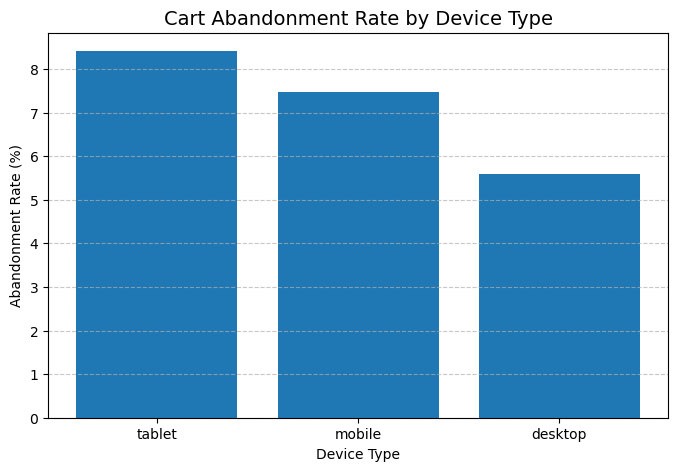

```python
# Group and aggregate
device_summary = (
    windows.groupby('device_category', as_index=False, observed=True)
    .agg(
        total_windows=('customer_id', 'count'),
        abandoned=('is_abandoned', 'sum'),
        missed=('missed_reorder', 'sum')
    )
)

# Calculate percentage rates
device_summary['abandon_rate (%)'] = (device_summary['abandoned'] / device_summary['total_windows'] * 100).round(2)
device_summary['missed_rate (%)'] = (device_summary['missed'] / device_summary['total_windows'] * 100).round(2)

# Sort by highest abandonment
device_summary = device_summary.sort_values('abandon_rate (%)', ascending=False)


# Data table
display(
    device_summary
    .style
    .format({'abandon_rate (%)': '{:.2f}%', 'missed_rate (%)': '{:.2f}%'})
    .background_gradient(subset=['abandon_rate (%)', 'missed_rate (%)'], cmap='Reds')
)


# Graph
plt.figure(figsize=(8,5))
plt.bar(device_summary['device_category'], device_summary['abandon_rate (%)'])
plt.title('Cart Abandonment Rate by Device Type', fontsize=14)
plt.xlabel('Device Type')
plt.ylabel('Abandonment Rate (%)')
plt.grid(axis='y', linestyle='--', alpha=0.7)
plt.show()
```

|  | cold_drink_channel_description | total_windows | abandoned | abandon_rate_% |
| --- | --- | --- | --- | --- |
| 7 | Store | 4471 | 341 | 7.63 |
| 5 | Institution | 2778 | 208 | 7.49 |
| 8 | Workplace | 2402 | 177 | 7.37 |
| 4 | Hotel | 3851 | 256 | 6.65 |
| 0 | Attraction | 4911 | 324 | 6.60 |
| 6 | Restaurant | 23770 | 1473 | 6.20 |
| 2 | Distributor | 4336 | 176 | 4.06 |
| 1 | Clinic | 1311 | 49 | 3.74 |
| 3 | Hot Beverage | 4651 | 88 | 1.89 |

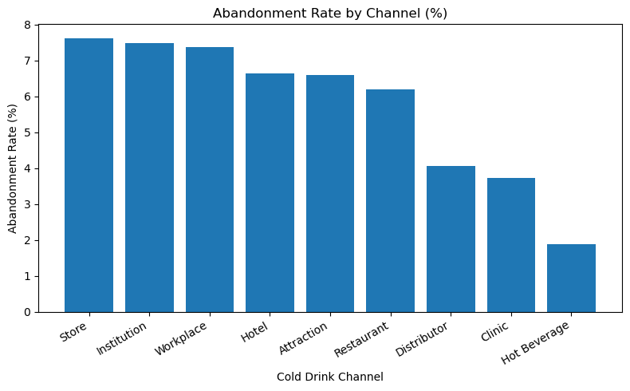

```python
# Merge channel info onto windows
tmp = windows[['customer_id','is_abandoned']].merge(
    customer[['customer_id','cold_drink_channel_description']].drop_duplicates(),
    on='customer_id', how='left'
)

# Group → counts + % abandoned
channel_df = (
    tmp.groupby('cold_drink_channel_description', as_index=False, observed=True)
       .agg(total_windows=('is_abandoned','size'),
            abandoned=('is_abandoned','sum'))
)
channel_df['abandon_rate_%'] = (channel_df['abandoned'] / channel_df['total_windows'] * 100).round(2)
channel_df = channel_df.sort_values('abandon_rate_%', ascending=False)

# Show table
display(channel_df.head(20))

# Plot %
plt.figure(figsize=(8,5))
plt.bar(channel_df['cold_drink_channel_description'].astype(str), channel_df['abandon_rate_%'])
plt.title("Abandonment Rate by Channel (%)")
plt.xlabel("Cold Drink Channel")
plt.ylabel("Abandonment Rate (%)")
plt.xticks(rotation=30, ha='right')
plt.tight_layout()
plt.show()
```

### b. Behavioral Patterns

|  | abandoned_flag(1=yes) | total_events | adds | removes | purchases |
| --- | --- | --- | --- | --- | --- |
| 0 | 0 | 56.23 | 3.73 | 0.74 | 0.65 |
| 1 | 1 | 68.53 | 4.55 | 1.77 | 0.00 |

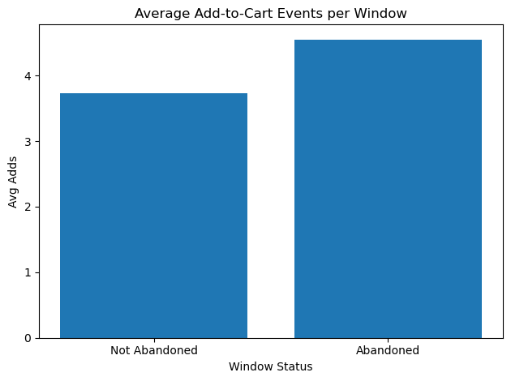

```python
# Count events per window
events_per_window = (
    ga2.groupby(['customer_id','next_order_date_utc'], observed=False)
       .agg(total_events=('event_name','size'),
            adds=('event_name', lambda s: (s.astype(str).str.lower()=='add_to_cart').sum()),
            removes=('event_name', lambda s: (s.astype(str).str.lower()=='remove_from_cart').sum()),
            purchases=('event_name', lambda s: (s.astype(str).str.lower()=='purchase').sum()))
       .reset_index()
)

behav = (
    windows[['customer_id','next_order_date_utc','is_abandoned']]
      .merge(events_per_window, on=['customer_id','next_order_date_utc'], how='left')
      .fillna({'total_events':0,'adds':0,'removes':0,'purchases':0})
)

behav_summary = (
    behav.groupby('is_abandoned', observed=False)[['total_events','adds','removes','purchases']]
         .mean()
         .round(2)
         .reset_index()
         .rename(columns={'is_abandoned':'abandoned_flag(1=yes)'})
)
display(behav_summary)

# average adds by abandon flag
plt.figure()
x = ['Not Abandoned','Abandoned']
vals = [
    behav_summary.loc[behav_summary['abandoned_flag(1=yes)']==0, 'adds'].values[0] if (behav_summary['abandoned_flag(1=yes)']==0).any() else 0,
    behav_summary.loc[behav_summary['abandoned_flag(1=yes)']==1, 'adds'].values[0] if (behav_summary['abandoned_flag(1=yes)']==1).any() else 0
]
plt.bar(x, vals)
plt.title("Average Add-to-Cart Events per Window")
plt.xlabel("Window Status")
plt.ylabel("Avg Adds")
plt.tight_layout()
plt.show()
```

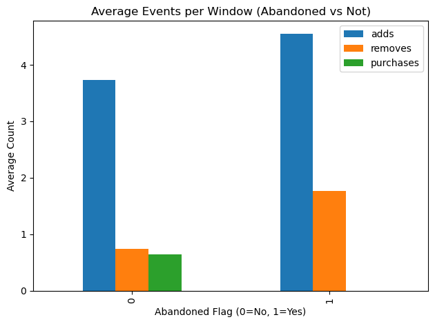

```python
behav_summary.plot(x='abandoned_flag(1=yes)', y=['adds','removes','purchases'], kind='bar')
plt.title("Average Events per Window (Abandoned vs Not)")
plt.xlabel("Abandoned Flag (0=No, 1=Yes)")
plt.ylabel("Average Count")
plt.tight_layout()
plt.show()
```

### d. Customer & Frequency

|  | customer_id | total_windows | abandoned | abandon_rate_% |
| --- | --- | --- | --- | --- |
| 3204 | 501636970 | 40 | 12 | 30.00 |
| 292 | 500435733 | 14 | 9 | 64.29 |
| 871 | 500993682 | 19 | 9 | 47.37 |
| 1016 | 501066849 | 32 | 9 | 28.12 |
| 5070 | 600058392 | 11 | 8 | 72.73 |
| 3840 | 501699737 | 25 | 8 | 32.00 |
| 1488 | 501267708 | 27 | 8 | 29.63 |
| 1105 | 501095132 | 13 | 7 | 53.85 |
| 3566 | 501676877 | 17 | 7 | 41.18 |
| 4159 | 501731583 | 19 | 7 | 36.84 |
| 3248 | 501642736 | 22 | 7 | 31.82 |
| 5729 | 600258935 | 24 | 7 | 29.17 |
| 4043 | 501723099 | 10 | 6 | 60.00 |
| 2750 | 501566747 | 11 | 6 | 54.55 |
| 1681 | 501368299 | 13 | 6 | 46.15 |
| 4353 | 501761258 | 14 | 6 | 42.86 |
| 118 | 500296865 | 16 | 6 | 37.50 |
| 3988 | 501711097 | 16 | 6 | 37.50 |
| 2186 | 501478449 | 17 | 6 | 35.29 |
| 722 | 500919200 | 21 | 6 | 28.57 |

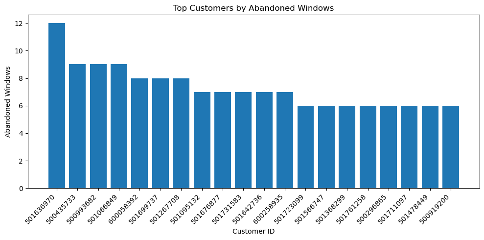

|  | frequency_days | total_windows | abandoned | abandon_rate_% |
| --- | --- | --- | --- | --- |
| 0 | 7 | 39988 | 2283 | 5.71 |
| 1 | 14 | 7495 | 462 | 6.16 |
| 2 | 28 | 4998 | 347 | 6.94 |

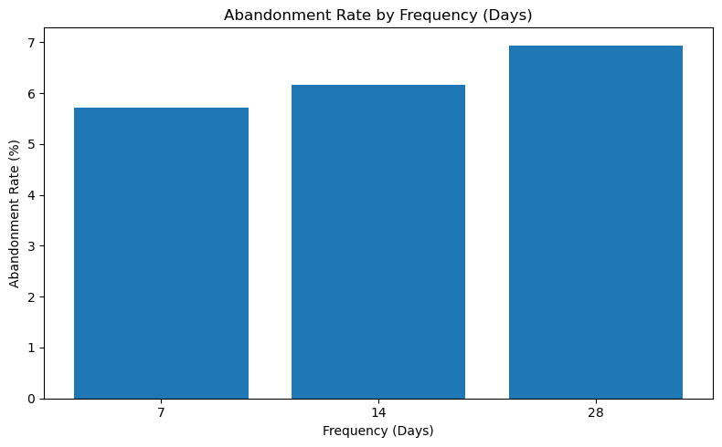

```python
# Customer-level summary
cust_df = (
    windows.groupby('customer_id', as_index=False, observed=True)
           .agg(total_windows=('is_abandoned','size'),
                abandoned=('is_abandoned','sum'))
)
cust_df['abandon_rate_%'] = (cust_df['abandoned'] / cust_df['total_windows'] * 100).round(2)

# Optional stability guardrail (keep customers with >= 5 windows)
cust_top = cust_df[cust_df['total_windows'] >= 5].copy() if not cust_df.empty else cust_df
cust_top = cust_top.sort_values(['abandoned','abandon_rate_%'], ascending=False).head(20)

display(cust_top)

plt.figure(figsize=(10,5))
plt.bar(cust_top['customer_id'].astype(str), cust_top['abandoned'].values)
plt.title('Top Customers by Abandoned Windows')
plt.xlabel('Customer ID')
plt.ylabel('Abandoned Windows')
plt.xticks(rotation=45, ha='right')
plt.tight_layout()
plt.show()


# Frequency (days) summary

# Prefer windows['frequency_days'] if present; else map from windows['frequency'] codes to days
freq_days = None
if 'frequency_days' in windows.columns:
    freq_days = windows[['customer_id','next_order_date_utc','frequency_days']].copy()
else:
    code_map = {'01':7,'1':7,1:7,'02':14,'2':14,2:14,'04':28,'4':28,4:28}
    if 'frequency' in windows.columns:
        tmp = windows[['customer_id','next_order_date_utc','frequency']].copy()
        tmp['frequency_days'] = (
            tmp['frequency'].map(code_map)
            .fillna(pd.to_numeric(tmp['frequency'], errors='coerce'))
        )
        freq_days = tmp[['customer_id','next_order_date_utc','frequency_days']]

# Attach frequency_days and compute
win_freq = windows.copy()
if freq_days is not None:
    win_freq = win_freq.merge(freq_days, on=['customer_id','next_order_date_utc'], how='left')

win_freq['frequency_days'] = pd.to_numeric(win_freq.get('frequency_days'), errors='coerce')
win_freq['frequency_days'] = win_freq['frequency_days'].round().astype('Int64')  # keep NA if missing

freq_df = (
    win_freq.groupby('frequency_days', as_index=False, observed=True)
            .agg(total_windows=('is_abandoned','size'),
                 abandoned=('is_abandoned','sum'))
)
freq_df['abandon_rate_%'] = (freq_df['abandoned'] / freq_df['total_windows'] * 100).round(2)
freq_df = freq_df.sort_values('frequency_days')

display(freq_df)

plt.figure(figsize=(8,5))
plt.bar(freq_df['frequency_days'].astype(str).fillna('Unknown'), freq_df['abandon_rate_%'].values)
plt.title('Abandonment Rate by Frequency (Days)')
plt.xlabel('Frequency (Days)')
plt.ylabel('Abandonment Rate (%)')
plt.tight_layout()
plt.show()
```

### e.Temporal Patterns

|  | month | abandon_rate_% |
| --- | --- | --- |
| 0 | 2024-06 | 1.139896 |
| 1 | 2024-07 | 2.834800 |
| 2 | 2024-08 | 4.348888 |
| 3 | 2024-09 | 4.885563 |
| 4 | 2024-10 | 7.418273 |
| 5 | 2024-11 | 6.476147 |
| 6 | 2024-12 | 5.981445 |
| 7 | 2025-01 | 6.288770 |
| 8 | 2025-02 | 6.208015 |
| 9 | 2025-03 | 6.619938 |
| 10 | 2025-04 | 5.687646 |
| 11 | 2025-05 | 6.232601 |
| 12 | 2025-06 | 12.060302 |

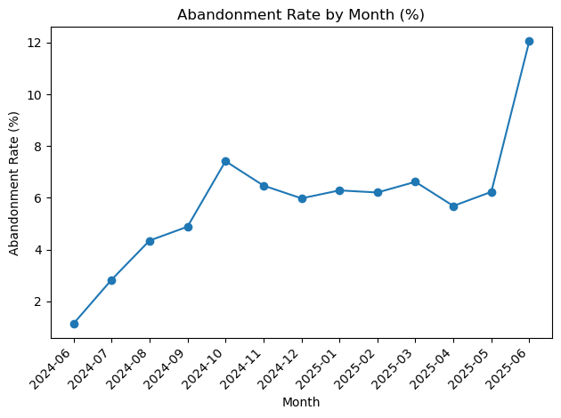

```python
# Ensure tz-aware → month string "YYYY-MM"
tmp = windows[['next_order_date_utc','is_abandoned']].copy()
tmp['next_order_date_utc'] = tmp['next_order_date_utc'].dt.tz_convert('UTC')

# Month label and proper sortable month key
tmp['month'] = tmp['next_order_date_utc'].dt.strftime('%Y-%m')
tmp['month_key'] = pd.to_datetime(tmp['month'], format='%Y-%m', errors='coerce')

abandon_by_month = (
    tmp.dropna(subset=['month_key'])
       .groupby('month', observed=False)['is_abandoned']
       .mean()
       .mul(100)
       .reset_index(name='abandon_rate_%')
       .assign(month_key=lambda d: pd.to_datetime(d['month'], format='%Y-%m'))
       .sort_values('month_key', kind='mergesort')  # stable sort
       .drop(columns=['month_key'])
)

display(abandon_by_month)

# Plot
plt.figure()
if not abandon_by_month.empty:
    plt.plot(abandon_by_month['month'], abandon_by_month['abandon_rate_%'], marker='o')
    plt.title("Abandonment Rate by Month (%)")
    plt.xlabel("Month")
    plt.ylabel("Abandonment Rate (%)")
    plt.xticks(rotation=45, ha='right')
    plt.tight_layout()
else:
    plt.title("Abandonment Rate by Month (%)\n(no data)")
    plt.axis('off')
plt.show()
```

### f.SKU

|  | material_id | added_count | abandoned_count | abandon_rate_% | trade_mark_desc | pack_type_desc | pack_size_desc | flavour_desc |
| --- | --- | --- | --- | --- | --- | --- | --- | --- |
| 150 | 119826 | 9453 | 678 | 7.17 | Oliver Originals | Plastic Bottle - Contour | 20 OZ | Vanilla Latte |
| 299 | 138334 | 8715 | 444 | 5.09 | Oliver Originals | Bag-In-Box | 5 GALLON | Vanilla Latte |
| 300 | 138335 | 6754 | 333 | 4.93 | Oliver Originals | Bag-In-Box | 5 GALLON | Vanilla Latte |
| 62 | 104631 | 4666 | 310 | 6.64 | Fizz Factory | CO2 Tank | 20 POUND | Tangerine |
| 70 | 112259 | 5958 | 300 | 5.04 | Blueberry Hill | Plastic Bottle - Other | 20 OZ | Vanilla Raspberry |
| 23 | 103029 | 5995 | 297 | 4.95 | Jack's Juices | Plastic Bottle - Dimple | 20 OZ | Cappuccino |
| 151 | 119827 | 6761 | 281 | 4.16 | Oliver Originals | Plastic Bottle - Contour | 20 OZ | Vanilla Latte |
| 301 | 138336 | 5994 | 274 | 4.57 | Jack's Juices | Bag-In-Box | 5 GALLON | Cappuccino |
| 163 | 121765 | 5027 | 243 | 4.83 | Oliver Originals | Plastic Bottle - Contour | 20 OZ | Vanilla Latte |
| 243 | 133129 | 2981 | 226 | 7.58 | Fizz Factory | Aluminum Can | 16 OZ | Berry Blast |
| 215 | 129254 | 4593 | 208 | 4.53 | Pete's Popcorn | Plastic Bottle - Other | 20 OZ | Vanilla Raspberry |
| 170 | 122366 | 2017 | 207 | 10.26 | Oliver Originals | Glass Bottle - Contour | 355 ML | Vanilla Latte |
| 167 | 122151 | 5094 | 197 | 3.87 | Oliver Originals | Bag-In-Box | 2.5 GALLON | Vanilla Latte |
| 274 | 135333 | 3333 | 195 | 5.85 | Fizz Factory | Plastic Bottle - Other | 18.5 OZ | Ginger Snap |
| 2 | 101728 | 3365 | 191 | 5.68 | Billy's Lemonade | Plastic Bottle - Other | 20 OZ | Banana |

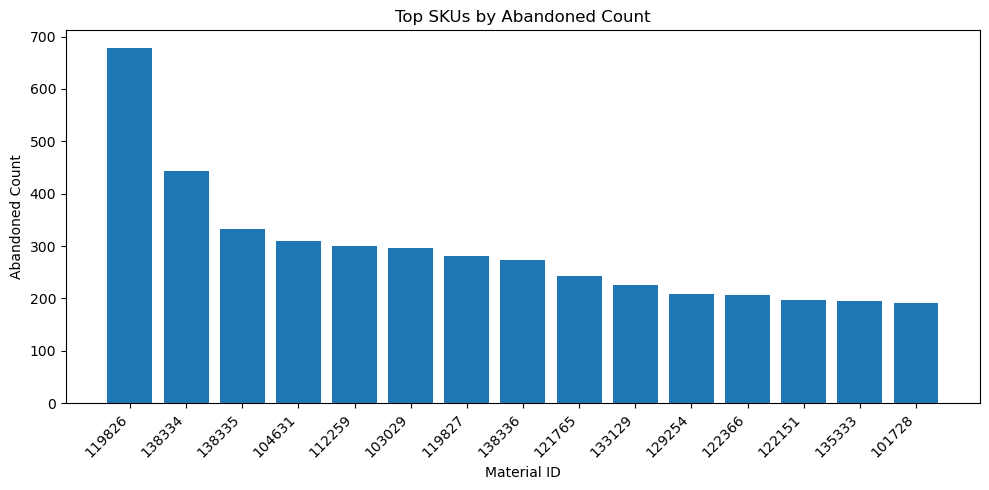

```python
# Add-to-cart events
adds = ga2.loc[ga2['event_name'].astype(str).str.lower().eq('add_to_cart'),
               ['customer_id','next_order_date_utc','items']].copy()

# Attach abandon label
adds = adds.merge(
    windows[['customer_id','next_order_date_utc','is_abandoned']],
    on=['customer_id','next_order_date_utc'], how='left'
).fillna({'is_abandoned':0})
adds['is_abandoned'] = adds['is_abandoned'].astype(int)

# Extract material_id(s) + explode
adds['material_id'] = adds['items'].astype(str).apply(lambda s: re.findall(r'\b\d{4,}\b', s))
adds = adds.explode('material_id').dropna(subset=['material_id'])
adds['material_id'] = adds['material_id'].astype(str)

# Aggregate per SKU → counts + % abandoned
sku = (adds.groupby('material_id', as_index=False, observed=True)
            .agg(added_count=('customer_id','size'),
                 abandoned_count=('is_abandoned','sum')))
sku['abandon_rate_%'] = (sku['abandoned_count'] / sku['added_count'] * 100).round(2)

# Join product attributes (align dtypes + flexible column names)
mat_id_col = 'material_id' if 'material_id' in material.columns else (
             'MATERIAL_ID' if 'MATERIAL_ID' in material.columns else None)
attrs = [c for c in ['trade_mark_desc','pack_type_desc','pack_size_desc','flavour_desc',
                     'TRADE_MARK_DESC','PACK_TYPE_DESC','PACK_SIZE_DESC','FLAVOUR_DESC']
         if c in material.columns]
if mat_id_col is not None:
    mat_small = material[[mat_id_col] + attrs].copy()
    mat_small[mat_id_col] = mat_small[mat_id_col].astype(str)   # ← key fix
    sku = sku.merge(mat_small, left_on='material_id', right_on=mat_id_col, how='left')
    if mat_id_col != 'material_id':
        sku = sku.drop(columns=[mat_id_col])

# Top 15 SKUs by abandoned_count
sku_top = sku.sort_values(['abandoned_count','abandon_rate_%'], ascending=False).head(15)
display(sku_top)

# Visualization: Top SKUs by abandoned count
plt.figure(figsize=(10,5))
plt.bar(sku_top['material_id'].astype(str), sku_top['abandoned_count'].values)
plt.title('Top SKUs by Abandoned Count')
plt.xlabel('Material ID')
plt.ylabel('Abandoned Count')
plt.xticks(rotation=45, ha='right')
plt.tight_layout()
plt.show()
```